# Risk Factor Analysis

## Outcome Variable

**Outcome Variable:** ever_co

## Predictor Variables

**Intervention Variable:** perdiar24

**Adjustment Set:**

- arm
- sex
- hfoodsec
- W_birthwt
- W_birthlen
- W_nrooms
- month
- brthmon
- impfloor
- impsan
- safeh20
- delta_hfoodsec
- delta_W_birthwt
- delta_W_birthlen
- delta_W_nrooms
- delta_month
- delta_brthmon
- delta_impfloor
- delta_impsan
- delta_safeh20

## Stratifying Variables

The analysis was stratified on these variable(s):

- agecat
- studyid
- country

## Data Summary

| agecat | studyid | country | perdiar24 | ever_co | n_cell | n |
| --- | --- | --- | --- | --- | --- | --- |
| 0-24 months | ki0047075b-MAL-ED | BANGLADESH | 0% | 0 | 18 | 263 |
| 0-24 months | ki0047075b-MAL-ED | BANGLADESH | 0% | 1 | 2 | 263 |
| 0-24 months | ki0047075b-MAL-ED | BANGLADESH | (0%, 5%] | 0 | 125 | 263 |
| 0-24 months | ki0047075b-MAL-ED | BANGLADESH | (0%, 5%] | 1 | 23 | 263 |
| 0-24 months | ki0047075b-MAL-ED | BANGLADESH | >5% | 0 | 81 | 263 |
| 0-24 months | ki0047075b-MAL-ED | BANGLADESH | >5% | 1 | 14 | 263 |
| 0-24 months | ki0047075b-MAL-ED | BRAZIL | 0% | 0 | 130 | 233 |
| 0-24 months | ki0047075b-MAL-ED | BRAZIL | 0% | 1 | 0 | 233 |
| 0-24 months | ki0047075b-MAL-ED | BRAZIL | (0%, 5%] | 0 | 99 | 233 |
| 0-24 months | ki0047075b-MAL-ED | BRAZIL | (0%, 5%] | 1 | 2 | 233 |
| 0-24 months | ki0047075b-MAL-ED | BRAZIL | >5% | 0 | 2 | 233 |
| 0-24 months | ki0047075b-MAL-ED | BRAZIL | >5% | 1 | 0 | 233 |
| 0-24 months | ki0047075b-MAL-ED | INDIA | 0% | 0 | 13 | 251 |
| 0-24 months | ki0047075b-MAL-ED | INDIA | 0% | 1 | 1 | 251 |
| 0-24 months | ki0047075b-MAL-ED | INDIA | (0%, 5%] | 0 | 149 | 251 |
| 0-24 months | ki0047075b-MAL-ED | INDIA | (0%, 5%] | 1 | 44 | 251 |
| 0-24 months | ki0047075b-MAL-ED | INDIA | >5% | 0 | 35 | 251 |
| 0-24 months | ki0047075b-MAL-ED | INDIA | >5% | 1 | 9 | 251 |
| 0-24 months | ki0047075b-MAL-ED | NEPAL | 0% | 0 | 16 | 240 |
| 0-24 months | ki0047075b-MAL-ED | NEPAL | 0% | 1 | 1 | 240 |
| 0-24 months | ki0047075b-MAL-ED | NEPAL | (0%, 5%] | 0 | 130 | 240 |
| 0-24 months | ki0047075b-MAL-ED | NEPAL | (0%, 5%] | 1 | 14 | 240 |
| 0-24 months | ki0047075b-MAL-ED | NEPAL | >5% | 0 | 73 | 240 |
| 0-24 months | ki0047075b-MAL-ED | NEPAL | >5% | 1 | 6 | 240 |
| 0-24 months | ki0047075b-MAL-ED | PERU | 0% | 0 | 28 | 302 |
| 0-24 months | ki0047075b-MAL-ED | PERU | 0% | 1 | 0 | 302 |
| 0-24 months | ki0047075b-MAL-ED | PERU | (0%, 5%] | 0 | 108 | 302 |
| 0-24 months | ki0047075b-MAL-ED | PERU | (0%, 5%] | 1 | 5 | 302 |
| 0-24 months | ki0047075b-MAL-ED | PERU | >5% | 0 | 154 | 302 |
| 0-24 months | ki0047075b-MAL-ED | PERU | >5% | 1 | 7 | 302 |

[output cut: 342 more lines]

The following strata were considered:

- agecat: 0-24 months, studyid: ki0047075b-MAL-ED, country: BANGLADESH
- agecat: 0-24 months, studyid: ki0047075b-MAL-ED, country: BRAZIL
- agecat: 0-24 months, studyid: ki0047075b-MAL-ED, country: INDIA
- agecat: 0-24 months, studyid: ki0047075b-MAL-ED, country: NEPAL
- agecat: 0-24 months, studyid: ki0047075b-MAL-ED, country: PERU
- agecat: 0-24 months, studyid: ki0047075b-MAL-ED, country: SOUTH AFRICA
- agecat: 0-24 months, studyid: ki0047075b-MAL-ED, country: TANZANIA, UNITED REPUBLIC OF
- agecat: 0-24 months, studyid: ki1000109-EE, country: PAKISTAN
- agecat: 0-24 months, studyid: ki1000109-ResPak, country: PAKISTAN
- agecat: 0-24 months, studyid: ki1000304b-SAS-FoodSuppl, country: INDIA
- agecat: 0-24 months, studyid: ki1017093-NIH-Birth, country: BANGLADESH
- agecat: 0-24 months, studyid: ki1017093b-PROVIDE, country: BANGLADESH
- agecat: 0-24 months, studyid: ki1017093c-NIH-Crypto, country: BANGLADESH
- agecat: 0-24 months, studyid: ki1112895-Guatemala BSC, country: GUATEMALA
- agecat: 0-24 months, studyid: ki1112895-iLiNS-Zinc, country: BURKINA FASO
- agecat: 0-24 months, studyid: ki1114097-CMIN, country: BANGLADESH
- agecat: 0-24 months, studyid: ki1114097-CMIN, country: BRAZIL
- agecat: 0-24 months, studyid: ki1114097-CMIN, country: GUINEA-BISSAU
- agecat: 0-24 months, studyid: ki1114097-CMIN, country: PERU
- agecat: 0-24 months, studyid: ki1114097-CONTENT, country: PERU
- agecat: 0-24 months, studyid: kiGH5241-JiVitA-4, country: BANGLADESH
- agecat: 0-6 months, studyid: ki0047075b-MAL-ED, country: BANGLADESH
- agecat: 0-6 months, studyid: ki0047075b-MAL-ED, country: BRAZIL
- agecat: 0-6 months, studyid: ki0047075b-MAL-ED, country: INDIA
- agecat: 0-6 months, studyid: ki0047075b-MAL-ED, country: NEPAL
- agecat: 0-6 months, studyid: ki0047075b-MAL-ED, country: PERU
- agecat: 0-6 months, studyid: ki0047075b-MAL-ED, country: SOUTH AFRICA
- agecat: 0-6 months, studyid: ki0047075b-MAL-ED, country: TANZANIA, UNITED REPUBLIC OF
- agecat: 0-6 months, studyid: ki1000109-EE, country: PAKISTAN
- agecat: 0-6 months, studyid: ki1000109-ResPak, country: PAKISTAN
- agecat: 0-6 months, studyid: ki1000304b-SAS-FoodSuppl, country: INDIA
- agecat: 0-6 months, studyid: ki1017093-NIH-Birth, country: BANGLADESH
- agecat: 0-6 months, studyid: ki1017093b-PROVIDE, country: BANGLADESH
- agecat: 0-6 months, studyid: ki1017093c-NIH-Crypto, country: BANGLADESH
- agecat: 0-6 months, studyid: ki1112895-Guatemala BSC, country: GUATEMALA
- agecat: 0-6 months, studyid: ki1114097-CMIN, country: BANGLADESH
- agecat: 0-6 months, studyid: ki1114097-CMIN, country: BRAZIL
- agecat: 0-6 months, studyid: ki1114097-CMIN, country: GUINEA-BISSAU
- agecat: 0-6 months, studyid: ki1114097-CMIN, country: PERU
- agecat: 0-6 months, studyid: ki1114097-CONTENT, country: PERU
- agecat: 0-6 months, studyid: kiGH5241-JiVitA-4, country: BANGLADESH
- agecat: 6-24 months, studyid: ki0047075b-MAL-ED, country: BANGLADESH
- agecat: 6-24 months, studyid: ki0047075b-MAL-ED, country: BRAZIL
- agecat: 6-24 months, studyid: ki0047075b-MAL-ED, country: INDIA
- agecat: 6-24 months, studyid: ki0047075b-MAL-ED, country: NEPAL
- agecat: 6-24 months, studyid: ki0047075b-MAL-ED, country: PERU
- agecat: 6-24 months, studyid: ki0047075b-MAL-ED, country: SOUTH AFRICA
- agecat: 6-24 months, studyid: ki0047075b-MAL-ED, country: TANZANIA, UNITED REPUBLIC OF
- agecat: 6-24 months, studyid: ki1000109-EE, country: PAKISTAN
- agecat: 6-24 months, studyid: ki1000109-ResPak, country: PAKISTAN
- agecat: 6-24 months, studyid: ki1000304b-SAS-FoodSuppl, country: INDIA
- agecat: 6-24 months, studyid: ki1017093-NIH-Birth, country: BANGLADESH
- agecat: 6-24 months, studyid: ki1017093b-PROVIDE, country: BANGLADESH
- agecat: 6-24 months, studyid: ki1017093c-NIH-Crypto, country: BANGLADESH
- agecat: 6-24 months, studyid: ki1112895-Guatemala BSC, country: GUATEMALA
- agecat: 6-24 months, studyid: ki1112895-iLiNS-Zinc, country: BURKINA FASO
- agecat: 6-24 months, studyid: ki1114097-CMIN, country: BANGLADESH
- agecat: 6-24 months, studyid: ki1114097-CMIN, country: BRAZIL
- agecat: 6-24 months, studyid: ki1114097-CMIN, country: GUINEA-BISSAU
- agecat: 6-24 months, studyid: ki1114097-CMIN, country: PERU
- agecat: 6-24 months, studyid: ki1114097-CONTENT, country: PERU
- agecat: 6-24 months, studyid: kiGH5241-JiVitA-4, country: BANGLADESH

### Dropped Strata

Some strata were dropped due to rare outcomes:

- agecat: 0-24 months, studyid: ki0047075b-MAL-ED, country: BANGLADESH
- agecat: 0-24 months, studyid: ki0047075b-MAL-ED, country: BRAZIL
- agecat: 0-24 months, studyid: ki0047075b-MAL-ED, country: INDIA
- agecat: 0-24 months, studyid: ki0047075b-MAL-ED, country: NEPAL
- agecat: 0-24 months, studyid: ki0047075b-MAL-ED, country: PERU
- agecat: 0-24 months, studyid: ki0047075b-MAL-ED, country: SOUTH AFRICA
- agecat: 0-24 months, studyid: ki0047075b-MAL-ED, country: TANZANIA, UNITED REPUBLIC OF
- agecat: 0-24 months, studyid: ki1000109-ResPak, country: PAKISTAN
- agecat: 0-24 months, studyid: ki1017093-NIH-Birth, country: BANGLADESH
- agecat: 0-24 months, studyid: ki1017093b-PROVIDE, country: BANGLADESH
- agecat: 0-24 months, studyid: ki1112895-Guatemala BSC, country: GUATEMALA
- agecat: 0-24 months, studyid: ki1114097-CMIN, country: BANGLADESH
- agecat: 0-24 months, studyid: ki1114097-CMIN, country: BRAZIL
- agecat: 0-24 months, studyid: ki1114097-CMIN, country: PERU
- agecat: 0-24 months, studyid: ki1114097-CONTENT, country: PERU
- agecat: 0-6 months, studyid: ki0047075b-MAL-ED, country: BANGLADESH
- agecat: 0-6 months, studyid: ki0047075b-MAL-ED, country: BRAZIL
- agecat: 0-6 months, studyid: ki0047075b-MAL-ED, country: INDIA
- agecat: 0-6 months, studyid: ki0047075b-MAL-ED, country: NEPAL
- agecat: 0-6 months, studyid: ki0047075b-MAL-ED, country: PERU
- agecat: 0-6 months, studyid: ki0047075b-MAL-ED, country: SOUTH AFRICA
- agecat: 0-6 months, studyid: ki0047075b-MAL-ED, country: TANZANIA, UNITED REPUBLIC OF
- agecat: 0-6 months, studyid: ki1000109-EE, country: PAKISTAN
- agecat: 0-6 months, studyid: ki1000109-ResPak, country: PAKISTAN
- agecat: 0-6 months, studyid: ki1017093-NIH-Birth, country: BANGLADESH
- agecat: 0-6 months, studyid: ki1017093b-PROVIDE, country: BANGLADESH
- agecat: 0-6 months, studyid: ki1017093c-NIH-Crypto, country: BANGLADESH
- agecat: 0-6 months, studyid: ki1112895-Guatemala BSC, country: GUATEMALA
- agecat: 0-6 months, studyid: ki1114097-CMIN, country: BANGLADESH
- agecat: 0-6 months, studyid: ki1114097-CMIN, country: BRAZIL
- agecat: 0-6 months, studyid: ki1114097-CMIN, country: GUINEA-BISSAU
- agecat: 0-6 months, studyid: ki1114097-CMIN, country: PERU
- agecat: 0-6 months, studyid: ki1114097-CONTENT, country: PERU
- agecat: 6-24 months, studyid: ki0047075b-MAL-ED, country: BANGLADESH
- agecat: 6-24 months, studyid: ki0047075b-MAL-ED, country: BRAZIL
- agecat: 6-24 months, studyid: ki0047075b-MAL-ED, country: INDIA
- agecat: 6-24 months, studyid: ki0047075b-MAL-ED, country: NEPAL
- agecat: 6-24 months, studyid: ki0047075b-MAL-ED, country: PERU
- agecat: 6-24 months, studyid: ki0047075b-MAL-ED, country: SOUTH AFRICA
- agecat: 6-24 months, studyid: ki0047075b-MAL-ED, country: TANZANIA, UNITED REPUBLIC OF
- agecat: 6-24 months, studyid: ki1000109-ResPak, country: PAKISTAN
- agecat: 6-24 months, studyid: ki1017093-NIH-Birth, country: BANGLADESH
- agecat: 6-24 months, studyid: ki1017093b-PROVIDE, country: BANGLADESH
- agecat: 6-24 months, studyid: ki1112895-Guatemala BSC, country: GUATEMALA
- agecat: 6-24 months, studyid: ki1114097-CMIN, country: BANGLADESH
- agecat: 6-24 months, studyid: ki1114097-CMIN, country: BRAZIL
- agecat: 6-24 months, studyid: ki1114097-CMIN, country: PERU
- agecat: 6-24 months, studyid: ki1114097-CONTENT, country: PERU

## Methods Detail

We’re interested in the causal parameters $E[Y_a]$ for all values of $a \in \mathcal{A}$. These parameters represent the mean outcome if, possibly contrary to fact, we intervened to set all units to have $A=a$. Under the randomization and positivity assumptions, these are identified by the statistical parameters $\psi_a=E_W[E_{Y|A,W}(Y|A=a,W)]$. In addition, we’re interested in the mean of $Y$, $E[Y]$ under no intervention (the observed mean). We will estimate these parameters by using SuperLearner to fit the relevant likelihood factors – $E_{Y|A,W}(Y|A=a,W)$ and $p(A=a|W)$, and then updating our likelihood fit using a joint TMLE.

For unadjusted analyses ($W=\{\}$), initial likelihoods were estimated using Lrnr_glm to estimate the simple $E(Y|A)$ and Lrnr_mean to estimate $p(A)$. For adjusted analyses, a small library containing Lrnr_glmnet, Lrnr_xgboost, and Lrnr_mean was used.

Having estimated these parameters, we will then use the delta method to estimate relative risks and attributable risks relative to a prespecified baseline level of $A$.

# Results Detail

## Results Plots

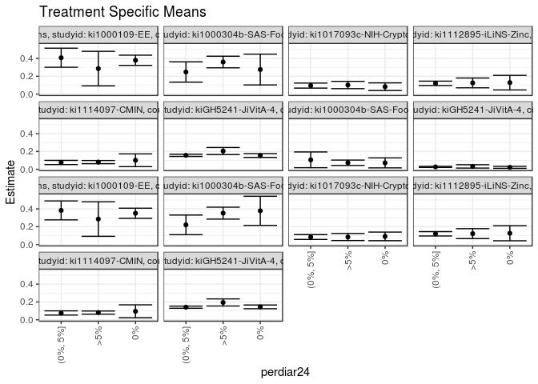

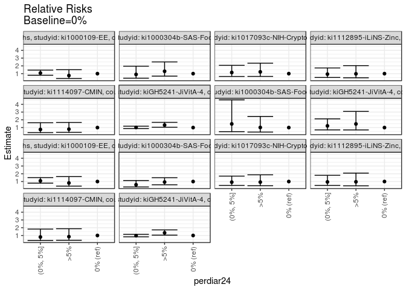

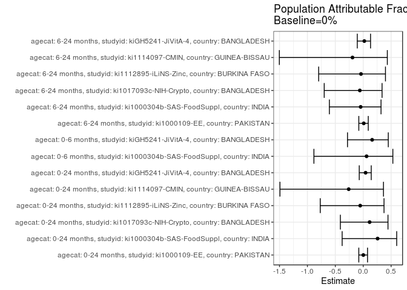

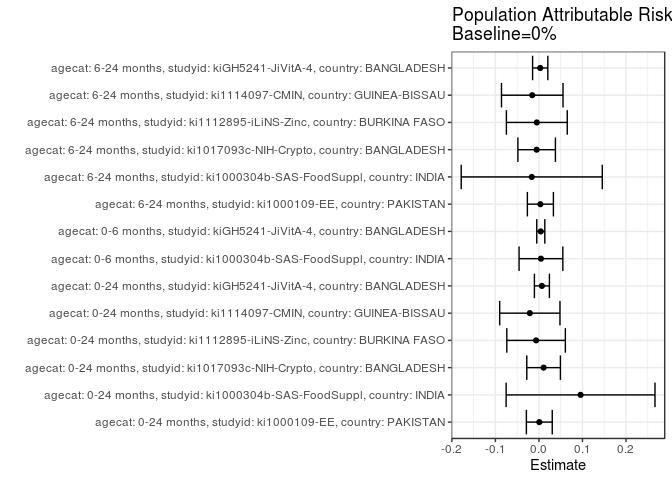

## Results Table

### Parameter: TSM

| agecat | studyid | country | intervention_level | baseline_level | estimate | ci_lower | ci_upper |
| --- | --- | --- | --- | --- | --- | --- | --- |
| 0-24 months | ki1000109-EE | PAKISTAN | 0% | NA | 0.3790614 | 0.3218528 | 0.4362699 |
| 0-24 months | ki1000109-EE | PAKISTAN | (0%, 5%] | NA | 0.4074074 | 0.3002624 | 0.5145524 |
| 0-24 months | ki1000109-EE | PAKISTAN | >5% | NA | 0.2857143 | 0.0922441 | 0.4791845 |
| 0-24 months | ki1000304b-SAS-FoodSuppl | INDIA | 0% | NA | 0.2751412 | 0.1026343 | 0.4476482 |
| 0-24 months | ki1000304b-SAS-FoodSuppl | INDIA | (0%, 5%] | NA | 0.2475586 | 0.1339284 | 0.3611888 |
| 0-24 months | ki1000304b-SAS-FoodSuppl | INDIA | >5% | NA | 0.3594941 | 0.2944943 | 0.4244940 |
| 0-24 months | ki1017093c-NIH-Crypto | BANGLADESH | 0% | NA | 0.0829296 | 0.0402235 | 0.1256356 |
| 0-24 months | ki1017093c-NIH-Crypto | BANGLADESH | (0%, 5%] | NA | 0.0952139 | 0.0670482 | 0.1233795 |
| 0-24 months | ki1017093c-NIH-Crypto | BANGLADESH | >5% | NA | 0.1018662 | 0.0609351 | 0.1427972 |
| 0-24 months | ki1112895-iLiNS-Zinc | BURKINA FASO | 0% | NA | 0.1284769 | 0.0465776 | 0.2103762 |
| 0-24 months | ki1112895-iLiNS-Zinc | BURKINA FASO | (0%, 5%] | NA | 0.1203722 | 0.0958684 | 0.1448761 |
| 0-24 months | ki1112895-iLiNS-Zinc | BURKINA FASO | >5% | NA | 0.1252630 | 0.0704397 | 0.1800863 |
| 0-24 months | ki1114097-CMIN | GUINEA-BISSAU | 0% | NA | 0.1014493 | 0.0301859 | 0.1727126 |
| 0-24 months | ki1114097-CMIN | GUINEA-BISSAU | (0%, 5%] | NA | 0.0767677 | 0.0533072 | 0.1002282 |
| 0-24 months | ki1114097-CMIN | GUINEA-BISSAU | >5% | NA | 0.0809628 | 0.0632727 | 0.0986529 |
| 0-24 months | kiGH5241-JiVitA-4 | BANGLADESH | 0% | NA | 0.1544946 | 0.1331859 | 0.1758033 |
| 0-24 months | kiGH5241-JiVitA-4 | BANGLADESH | (0%, 5%] | NA | 0.1571399 | 0.1445592 | 0.1697207 |
| 0-24 months | kiGH5241-JiVitA-4 | BANGLADESH | >5% | NA | 0.2048616 | 0.1654694 | 0.2442539 |
| 0-6 months | ki1000304b-SAS-FoodSuppl | INDIA | 0% | NA | 0.0722892 | 0.0165097 | 0.1280686 |
| 0-6 months | ki1000304b-SAS-FoodSuppl | INDIA | (0%, 5%] | NA | 0.1063830 | 0.0181291 | 0.1946368 |
| 0-6 months | ki1000304b-SAS-FoodSuppl | INDIA | >5% | NA | 0.0734266 | 0.0431606 | 0.1036925 |
| 0-6 months | kiGH5241-JiVitA-4 | BANGLADESH | 0% | NA | 0.0222728 | 0.0109923 | 0.0335532 |
| 0-6 months | kiGH5241-JiVitA-4 | BANGLADESH | (0%, 5%] | NA | 0.0272284 | 0.0210128 | 0.0334441 |
| 0-6 months | kiGH5241-JiVitA-4 | BANGLADESH | >5% | NA | 0.0326972 | 0.0137416 | 0.0516528 |
| 6-24 months | ki1000109-EE | PAKISTAN | 0% | NA | 0.3505535 | 0.2936688 | 0.4074382 |
| 6-24 months | ki1000109-EE | PAKISTAN | (0%, 5%] | NA | 0.3827160 | 0.2767250 | 0.4887071 |
| 6-24 months | ki1000109-EE | PAKISTAN | >5% | NA | 0.2857143 | 0.0922400 | 0.4791886 |
| 6-24 months | ki1000304b-SAS-FoodSuppl | INDIA | 0% | NA | 0.3780964 | 0.2151330 | 0.5410597 |
| 6-24 months | ki1000304b-SAS-FoodSuppl | INDIA | (0%, 5%] | NA | 0.2207412 | 0.1106320 | 0.3308505 |
| 6-24 months | ki1000304b-SAS-FoodSuppl | INDIA | >5% | NA | 0.3520188 | 0.2850763 | 0.4189612 |
| 6-24 months | ki1017093c-NIH-Crypto | BANGLADESH | 0% | NA | 0.0915359 | 0.0433007 | 0.1397710 |
| 6-24 months | ki1017093c-NIH-Crypto | BANGLADESH | (0%, 5%] | NA | 0.0843271 | 0.0573198 | 0.1113344 |
| 6-24 months | ki1017093c-NIH-Crypto | BANGLADESH | >5% | NA | 0.0846564 | 0.0451229 | 0.1241900 |
| 6-24 months | ki1112895-iLiNS-Zinc | BURKINA FASO | 0% | NA | 0.1267821 | 0.0422076 | 0.2113566 |
| 6-24 months | ki1112895-iLiNS-Zinc | BURKINA FASO | (0%, 5%] | NA | 0.1204330 | 0.0960612 | 0.1448049 |
| 6-24 months | ki1112895-iLiNS-Zinc | BURKINA FASO | >5% | NA | 0.1222715 | 0.0665345 | 0.1780084 |
| 6-24 months | ki1114097-CMIN | GUINEA-BISSAU | 0% | NA | 0.0952381 | 0.0227278 | 0.1677484 |
| 6-24 months | ki1114097-CMIN | GUINEA-BISSAU | (0%, 5%] | NA | 0.0764463 | 0.0527661 | 0.1001264 |
| 6-24 months | ki1114097-CMIN | GUINEA-BISSAU | >5% | NA | 0.0806630 | 0.0629150 | 0.0984109 |
| 6-24 months | kiGH5241-JiVitA-4 | BANGLADESH | 0% | NA | 0.1447922 | 0.1239960 | 0.1655883 |
| 6-24 months | kiGH5241-JiVitA-4 | BANGLADESH | (0%, 5%] | NA | 0.1412013 | 0.1291399 | 0.1532628 |
| 6-24 months | kiGH5241-JiVitA-4 | BANGLADESH | >5% | NA | 0.1941354 | 0.1543247 | 0.2339460 |

### Parameter: E(Y)

| agecat | studyid | country | intervention_level | baseline_level | estimate | ci_lower | ci_upper |
| --- | --- | --- | --- | --- | --- | --- | --- |
| 0-24 months | ki1000109-EE | PAKISTAN | NA | NA | 0.3799472 | 0.3310169 | 0.4288776 |
| 0-24 months | ki1000304b-SAS-FoodSuppl | INDIA | NA | NA | 0.3708134 | 0.3244530 | 0.4171738 |
| 0-24 months | ki1017093c-NIH-Crypto | BANGLADESH | NA | NA | 0.0936675 | 0.0729118 | 0.1144233 |
| 0-24 months | ki1112895-iLiNS-Zinc | BURKINA FASO | NA | NA | 0.1219413 | 0.0960094 | 0.1478731 |
| 0-24 months | ki1114097-CMIN | GUINEA-BISSAU | NA | NA | 0.0805142 | 0.0666381 | 0.0943903 |
| 0-24 months | kiGH5241-JiVitA-4 | BANGLADESH | NA | NA | 0.1613377 | 0.1500062 | 0.1726692 |
| 0-6 months | ki1000304b-SAS-FoodSuppl | INDIA | NA | NA | 0.0769231 | 0.0512858 | 0.1025603 |
| 0-6 months | kiGH5241-JiVitA-4 | BANGLADESH | NA | NA | 0.0265122 | 0.0211694 | 0.0318550 |
| 6-24 months | ki1000109-EE | PAKISTAN | NA | NA | 0.3538874 | 0.3052956 | 0.4024792 |
| 6-24 months | ki1000304b-SAS-FoodSuppl | INDIA | NA | NA | 0.3615960 | 0.3145115 | 0.4086805 |
| 6-24 months | ki1017093c-NIH-Crypto | BANGLADESH | NA | NA | 0.0863014 | 0.0659171 | 0.1066856 |
| 6-24 months | ki1112895-iLiNS-Zinc | BURKINA FASO | NA | NA | 0.1219413 | 0.0960094 | 0.1478731 |
| 6-24 months | ki1114097-CMIN | GUINEA-BISSAU | NA | NA | 0.0798898 | 0.0659396 | 0.0938400 |
| 6-24 months | kiGH5241-JiVitA-4 | BANGLADESH | NA | NA | 0.1477252 | 0.1371297 | 0.1583206 |

### Parameter: RR

| agecat | studyid | country | intervention_level | baseline_level | estimate | ci_lower | ci_upper |
| --- | --- | --- | --- | --- | --- | --- | --- |
| 0-24 months | ki1000109-EE | PAKISTAN | 0% | 0% | 1.0000000 | 1.0000000 | 1.000000 |
| 0-24 months | ki1000109-EE | PAKISTAN | (0%, 5%] | 0% | 1.0747795 | 0.7936567 | 1.455480 |
| 0-24 months | ki1000109-EE | PAKISTAN | >5% | 0% | 0.7537415 | 0.3766397 | 1.508408 |
| 0-24 months | ki1000304b-SAS-FoodSuppl | INDIA | 0% | 0% | 1.0000000 | 1.0000000 | 1.000000 |
| 0-24 months | ki1000304b-SAS-FoodSuppl | INDIA | (0%, 5%] | 0% | 0.8997511 | 0.4129180 | 1.960564 |
| 0-24 months | ki1000304b-SAS-FoodSuppl | INDIA | >5% | 0% | 1.3065804 | 0.6800820 | 2.510216 |
| 0-24 months | ki1017093c-NIH-Crypto | BANGLADESH | 0% | 0% | 1.0000000 | 1.0000000 | 1.000000 |
| 0-24 months | ki1017093c-NIH-Crypto | BANGLADESH | (0%, 5%] | 0% | 1.1481294 | 0.6370977 | 2.069072 |
| 0-24 months | ki1017093c-NIH-Crypto | BANGLADESH | >5% | 0% | 1.2283456 | 0.6421587 | 2.349626 |
| 0-24 months | ki1112895-iLiNS-Zinc | BURKINA FASO | 0% | 0% | 1.0000000 | 1.0000000 | 1.000000 |
| 0-24 months | ki1112895-iLiNS-Zinc | BURKINA FASO | (0%, 5%] | 0% | 0.9369172 | 0.5071198 | 1.730979 |
| 0-24 months | ki1112895-iLiNS-Zinc | BURKINA FASO | >5% | 0% | 0.9749848 | 0.4675922 | 2.032958 |
| 0-24 months | ki1114097-CMIN | GUINEA-BISSAU | 0% | 0% | 1.0000000 | 1.0000000 | 1.000000 |
| 0-24 months | ki1114097-CMIN | GUINEA-BISSAU | (0%, 5%] | 0% | 0.7567100 | 0.3517529 | 1.627875 |
| 0-24 months | ki1114097-CMIN | GUINEA-BISSAU | >5% | 0% | 0.7980619 | 0.3824263 | 1.665426 |
| 0-24 months | kiGH5241-JiVitA-4 | BANGLADESH | 0% | 0% | 1.0000000 | 1.0000000 | 1.000000 |
| 0-24 months | kiGH5241-JiVitA-4 | BANGLADESH | (0%, 5%] | 0% | 1.0171224 | 0.8756399 | 1.181465 |
| 0-24 months | kiGH5241-JiVitA-4 | BANGLADESH | >5% | 0% | 1.3260116 | 1.0485528 | 1.676889 |
| 0-6 months | ki1000304b-SAS-FoodSuppl | INDIA | 0% | 0% | 1.0000000 | 1.0000000 | 1.000000 |
| 0-6 months | ki1000304b-SAS-FoodSuppl | INDIA | (0%, 5%] | 0% | 1.4716312 | 0.4739794 | 4.569182 |
| 0-6 months | ki1000304b-SAS-FoodSuppl | INDIA | >5% | 0% | 1.0157343 | 0.4235009 | 2.436161 |
| 0-6 months | kiGH5241-JiVitA-4 | BANGLADESH | 0% | 0% | 1.0000000 | 1.0000000 | 1.000000 |
| 0-6 months | kiGH5241-JiVitA-4 | BANGLADESH | (0%, 5%] | 0% | 1.2224989 | 0.7028046 | 2.126485 |
| 0-6 months | kiGH5241-JiVitA-4 | BANGLADESH | >5% | 0% | 1.4680363 | 0.6979072 | 3.087990 |
| 6-24 months | ki1000109-EE | PAKISTAN | 0% | 0% | 1.0000000 | 1.0000000 | 1.000000 |
| 6-24 months | ki1000109-EE | PAKISTAN | (0%, 5%] | 0% | 1.0917479 | 0.7919927 | 1.504955 |
| 6-24 months | ki1000109-EE | PAKISTAN | >5% | 0% | 0.8150376 | 0.4062231 | 1.635274 |
| 6-24 months | ki1000304b-SAS-FoodSuppl | INDIA | 0% | 0% | 1.0000000 | 1.0000000 | 1.000000 |
| 6-24 months | ki1000304b-SAS-FoodSuppl | INDIA | (0%, 5%] | 0% | 0.5838227 | 0.3017944 | 1.129408 |
| 6-24 months | ki1000304b-SAS-FoodSuppl | INDIA | >5% | 0% | 0.9310292 | 0.5811085 | 1.491658 |
| 6-24 months | ki1017093c-NIH-Crypto | BANGLADESH | 0% | 0% | 1.0000000 | 1.0000000 | 1.000000 |
| 6-24 months | ki1017093c-NIH-Crypto | BANGLADESH | (0%, 5%] | 0% | 0.9212468 | 0.4998180 | 1.698009 |
| 6-24 months | ki1017093c-NIH-Crypto | BANGLADESH | >5% | 0% | 0.9248445 | 0.4590946 | 1.863096 |
| 6-24 months | ki1112895-iLiNS-Zinc | BURKINA FASO | 0% | 0% | 1.0000000 | 1.0000000 | 1.000000 |
| 6-24 months | ki1112895-iLiNS-Zinc | BURKINA FASO | (0%, 5%] | 0% | 0.9499213 | 0.5010375 | 1.800964 |
| 6-24 months | ki1112895-iLiNS-Zinc | BURKINA FASO | >5% | 0% | 0.9644223 | 0.4460972 | 2.084995 |
| 6-24 months | ki1114097-CMIN | GUINEA-BISSAU | 0% | 0% | 1.0000000 | 1.0000000 | 1.000000 |
| 6-24 months | ki1114097-CMIN | GUINEA-BISSAU | (0%, 5%] | 0% | 0.8026860 | 0.3528359 | 1.826075 |
| 6-24 months | ki1114097-CMIN | GUINEA-BISSAU | >5% | 0% | 0.8469613 | 0.3834239 | 1.870889 |
| 6-24 months | kiGH5241-JiVitA-4 | BANGLADESH | 0% | 0% | 1.0000000 | 1.0000000 | 1.000000 |
| 6-24 months | kiGH5241-JiVitA-4 | BANGLADESH | (0%, 5%] | 0% | 0.9752002 | 0.8278286 | 1.148807 |
| 6-24 months | kiGH5241-JiVitA-4 | BANGLADESH | >5% | 0% | 1.3407864 | 1.0439361 | 1.722048 |

### Parameter: PAR

| agecat | studyid | country | intervention_level | baseline_level | estimate | ci_lower | ci_upper |
| --- | --- | --- | --- | --- | --- | --- | --- |
| 0-24 months | ki1000109-EE | PAKISTAN | 0% | NA | 0.0008859 | -0.0288291 | 0.0306009 |
| 0-24 months | ki1000304b-SAS-FoodSuppl | INDIA | 0% | NA | 0.0956722 | -0.0753442 | 0.2666886 |
| 0-24 months | ki1017093c-NIH-Crypto | BANGLADESH | 0% | NA | 0.0107380 | -0.0278933 | 0.0493693 |
| 0-24 months | ki1112895-iLiNS-Zinc | BURKINA FASO | 0% | NA | -0.0065356 | -0.0737837 | 0.0607125 |
| 0-24 months | ki1114097-CMIN | GUINEA-BISSAU | 0% | NA | -0.0209351 | -0.0901943 | 0.0483241 |
| 0-24 months | kiGH5241-JiVitA-4 | BANGLADESH | 0% | NA | 0.0068431 | -0.0103984 | 0.0240847 |
| 0-6 months | ki1000304b-SAS-FoodSuppl | INDIA | 0% | NA | 0.0046339 | -0.0456361 | 0.0549039 |
| 0-6 months | kiGH5241-JiVitA-4 | BANGLADESH | 0% | NA | 0.0042394 | -0.0050147 | 0.0134936 |
| 6-24 months | ki1000109-EE | PAKISTAN | 0% | NA | 0.0033339 | -0.0265835 | 0.0332513 |
| 6-24 months | ki1000304b-SAS-FoodSuppl | INDIA | 0% | NA | -0.0165003 | -0.1785370 | 0.1455363 |
| 6-24 months | ki1017093c-NIH-Crypto | BANGLADESH | 0% | NA | -0.0052345 | -0.0483570 | 0.0378880 |
| 6-24 months | ki1112895-iLiNS-Zinc | BURKINA FASO | 0% | NA | -0.0048408 | -0.0747630 | 0.0650814 |
| 6-24 months | ki1114097-CMIN | GUINEA-BISSAU | 0% | NA | -0.0153483 | -0.0860314 | 0.0553348 |
| 6-24 months | kiGH5241-JiVitA-4 | BANGLADESH | 0% | NA | 0.0029330 | -0.0145807 | 0.0204468 |

### Parameter: PAF

| agecat | studyid | country | intervention_level | baseline_level | estimate | ci_lower | ci_upper |
| --- | --- | --- | --- | --- | --- | --- | --- |
| 0-24 months | ki1000109-EE | PAKISTAN | 0% | NA | 0.0023315 | -0.0790239 | 0.0775530 |
| 0-24 months | ki1000304b-SAS-FoodSuppl | INDIA | 0% | NA | 0.2580062 | -0.3773599 | 0.6002826 |
| 0-24 months | ki1017093c-NIH-Crypto | BANGLADESH | 0% | NA | 0.1146392 | -0.4094190 | 0.4438391 |
| 0-24 months | ki1112895-iLiNS-Zinc | BURKINA FASO | 0% | NA | -0.0535966 | -0.7700977 | 0.3728788 |
| 0-24 months | ki1114097-CMIN | GUINEA-BISSAU | 0% | NA | -0.2600171 | -1.4920380 | 0.3629138 |
| 0-24 months | kiGH5241-JiVitA-4 | BANGLADESH | 0% | NA | 0.0424150 | -0.0709304 | 0.1437641 |
| 0-6 months | ki1000304b-SAS-FoodSuppl | INDIA | 0% | NA | 0.0602410 | -0.8832383 | 0.5310487 |
| 0-6 months | kiGH5241-JiVitA-4 | BANGLADESH | 0% | NA | 0.1599045 | -0.2815045 | 0.4492720 |
| 6-24 months | ki1000109-EE | PAKISTAN | 0% | NA | 0.0094208 | -0.0788317 | 0.0904539 |
| 6-24 months | ki1000304b-SAS-FoodSuppl | INDIA | 0% | NA | -0.0456320 | -0.6062963 | 0.3193371 |
| 6-24 months | ki1017093c-NIH-Crypto | BANGLADESH | 0% | NA | -0.0606536 | -0.6985626 | 0.3376835 |
| 6-24 months | ki1112895-iLiNS-Zinc | BURKINA FASO | 0% | NA | -0.0396980 | -0.7984601 | 0.3989459 |
| 6-24 months | ki1114097-CMIN | GUINEA-BISSAU | 0% | NA | -0.1921182 | -1.5029787 | 0.4322181 |
| 6-24 months | kiGH5241-JiVitA-4 | BANGLADESH | 0% | NA | 0.0198546 | -0.1062379 | 0.1315747 |